[figure not shown]

# CP5. [실습] 데이터 전처리와 시각화: 주가분석

- 본 실습은 간단한 데이터 시각화 방법을 직접 체험하기 위한 것입니다.
- 차트를 화려하게 꾸미는데 목적을 두지 말고 전처리 부분에 중점을 두는 것이 좋습니다.
- 우선 다음과 같은 과정으로 데이터 시각화를 수행함으로 알고 진행하기 바랍니다.

[figure not shown]

```python
# 라이브러리 불러오기
import numpy as np
import pandas as pd
import matplotlib.pyplot as plt
import matplotlib.image as mpimg

%matplotlib inline
%config InlineBackend.figure_format = 'retina'
```

## 1. 데이터 불러오기

- read_csv() 함수를 사용해 분석할 데이터를 csv 파일에서 불러옵니다.
- stock 데이터 셋은 2000 ~ 2019년 해외 A기업 주식정보입니다.
- 데이터프레임 이름은 **stock**으로 합니다.
- 날짜 정보를 손쉽게 처리하기 위해 **pd.to_datetime()** 함수를 사용해 **Date** 열은 **datetime** 형식으로 변경합니다.
- 파일 경로: 'https://raw.githubusercontent.com/Jangrae/csv/master/stock.csv'

```python
# stock
file_path = 'https://raw.githubusercontent.com/Jangrae/csv/master/stock.csv'
stock = pd.read_csv(file_path)

# datetime 형으로 변경
stock.Date = pd.to_datetime(stock.Date)
```

## 2. 데이터 확인

- 데이터를 알아야 데이터를 분석할 수 있습니다.
- 우선 분석할 데이터가 어떤 형태의 데이터인지 확인합니다.

**1) 상위/하위 데이터 확인**

- **head()**, **tail()** 메소드로 상/하위 데이터를 확인합니다.

```python
# 상위 5개 행 확인
stock.head()
```

|  | Date | High | Low | Open | Close | Volume | Adj Close |
| --- | --- | --- | --- | --- | --- | --- | --- |
| 0 | 2000-01-03 | 4.017857 | 3.631696 | 3.745536 | 3.997768 | 133949200 | 3.470226 |
| 1 | 2000-01-04 | 3.950893 | 3.613839 | 3.866071 | 3.660714 | 128094400 | 3.177650 |
| 2 | 2000-01-05 | 3.948661 | 3.678571 | 3.705357 | 3.714286 | 194580400 | 3.224152 |
| 3 | 2000-01-06 | 3.821429 | 3.392857 | 3.790179 | 3.392857 | 191993200 | 2.945139 |
| 4 | 2000-01-07 | 3.607143 | 3.410714 | 3.446429 | 3.553571 | 115183600 | 3.084645 |

```python
# 하위 5개 행 확인
stock.tail()
```

|  | Date | High | Low | Open | Close | Volume | Adj Close |
| --- | --- | --- | --- | --- | --- | --- | --- |
| 5026 | 2019-12-24 | 284.890015 | 282.920013 | 284.690002 | 284.269989 | 12119700 | 283.596924 |
| 5027 | 2019-12-26 | 289.980011 | 284.700012 | 284.820007 | 289.910004 | 23280300 | 289.223602 |
| 5028 | 2019-12-27 | 293.970001 | 288.119995 | 291.119995 | 289.799988 | 36566500 | 289.113831 |
| 5029 | 2019-12-30 | 292.690002 | 285.220001 | 289.459992 | 291.519989 | 36028600 | 290.829773 |
| 5030 | 2019-12-31 | 293.679993 | 289.519989 | 289.929993 | 293.649994 | 25201400 | 292.954712 |

**2) 열 데이터 개수, NaN 값 여부 확인**

- **info()** 메소드로 각 열의 값 개수, **NaN**값 포함 여부를 확인합니다.
- NaN값이 포함되어 있으면 결측치에 대한 해결(제거 또는 변경)이 필요합니다.

```python
# 열 정보, NaN 값 포함 여부 확인
stock.info()
```

```
<class 'pandas.core.frame.DataFrame'>
RangeIndex: 5031 entries, 0 to 5030
Data columns (total 7 columns):
 #   Column     Non-Null Count  Dtype
---  ------     --------------  -----
 0   Date       5031 non-null   datetime64[ns]
 1   High       5031 non-null   float64
 2   Low        5031 non-null   float64
 3   Open       5031 non-null   float64
 4   Close      5031 non-null   float64
 5   Volume     5031 non-null   int64
 6   Adj Close  5031 non-null   float64
dtypes: datetime64[ns](1), float64(5), int64(1)
memory usage: 275.3 KB
```

**3) 기초 통계 정보 확인**

- **describe()** 메소드를 사용해 기초 통계 정보를 확인합니다.

```python
# 기초 통계 정보 확인
stock.describe()
```

|  | High | Low | Open | Close | Volume | Adj Close |
| --- | --- | --- | --- | --- | --- | --- |
| count | 5031.000000 | 5031.000000 | 5031.000000 | 5031.000000 | 5.031000e+03 | 5031.000000 |
| mean | 60.052092 | 58.916362 | 59.493094 | 59.503741 | 1.149430e+08 | 55.667863 |
| std | 65.302285 | 64.235383 | 64.752822 | 64.800571 | 9.877368e+07 | 63.229538 |
| min | 0.942143 | 0.908571 | 0.927857 | 0.937143 | 9.835000e+06 | 0.813478 |
| 25% | 5.007500 | 4.784431 | 4.907679 | 4.907143 | 4.724460e+07 | 4.259600 |
| 50% | 29.242857 | 28.585714 | 28.911428 | 28.925714 | 8.732500e+07 | 25.108700 |
| 75% | 100.276428 | 98.385002 | 99.165001 | 99.480000 | 1.516658e+08 | 91.943821 |
| max | 293.970001 | 289.519989 | 291.119995 | 293.649994 | 1.855410e+09 | 292.954712 |

**4) 질문**

- stock 데이터가 분석하기에 적절한 형태인가요?
- stock 데이터에 대해 어떤 분석이 의미가 있을까요?
- 분석에 걸림돌이 될 만한 것은 무엇일까요?
- 분석을 위해 우선 어떤 처리를 해야 할까요?

## 3. 데이터 전처리

- NaN 값이 포함된 열이 있으면 제거하거나 다른 값으로 채워야 합니다.
- 중복된 데이터는 정확한 분석을 방해하므로 제거해야 합니다.
- 기타 데이터에 방해가 되는 요소를 전처리 과정에서 제거합니다.

**1) 불필요한 열 제거**

- 분석에 불필요한 열은 과감히 제거합니다.
- 본 예제에서는 Volume, Adj Close 열을 의미 없다고 간주하고 제거합니다.

```python
# Volume, Adj Close 열 제거
stock.drop(['Volume', 'Adj Close'], axis=1, inplace=True)

# 확인
stock.head()
```

|  | Date | High | Low | Open | Close |
| --- | --- | --- | --- | --- | --- |
| 0 | 2000-01-03 | 4.017857 | 3.631696 | 3.745536 | 3.997768 |
| 1 | 2000-01-04 | 3.950893 | 3.613839 | 3.866071 | 3.660714 |
| 2 | 2000-01-05 | 3.948661 | 3.678571 | 3.705357 | 3.714286 |
| 3 | 2000-01-06 | 3.821429 | 3.392857 | 3.790179 | 3.392857 |
| 4 | 2000-01-07 | 3.607143 | 3.410714 | 3.446429 | 3.553571 |

**2) 열 이름 변경**

- 이후 분석을 위해 열 이름을 쉽게 이해햘 수 있는 이름으로 변경합니다.
- 대소문자를 구분하므로 대문자인지 소문자인지 고민하지 않기 위해 소문자만 사용하는 것이 좋습니다.
- 열 이름 변경은 일반적으로 **rename()** 메소드를 사용합니다.
- 하지만 많은 열, 특히 모든 열 이름을 바꿀 때는 **columns** 속성을 바꾸는 게 더 쉽습니다.

```python
# 열 이름 변경
stock.columns = ['date', 'high', 'low', 'open', 'close']

# 확인
stock.head()
```

|  | date | high | low | open | close |
| --- | --- | --- | --- | --- | --- |
| 0 | 2000-01-03 | 4.017857 | 3.631696 | 3.745536 | 3.997768 |
| 1 | 2000-01-04 | 3.950893 | 3.613839 | 3.866071 | 3.660714 |
| 2 | 2000-01-05 | 3.948661 | 3.678571 | 3.705357 | 3.714286 |
| 3 | 2000-01-06 | 3.821429 | 3.392857 | 3.790179 | 3.392857 |
| 4 | 2000-01-07 | 3.607143 | 3.410714 | 3.446429 | 3.553571 |

**3) 대상 데이터 줄이기**

- 전체 데이터가 분석 대상이 아니라면 필요한 데이터만 별도로 추출합니다.
- 2000 ~ 2019년 데이터 중에서 **2015 ~ 2019** 데이터만 사용하기로 합니다.
- stock 데이터프레임은 그대로 두고 **stock1519** 데이터프레임을 만들도록 합니다.
- 일부 데이터만 추출해 새로운 데이터프레임으로 복사할 떄는 **.copy()**를 맨 뒤에 붙입니다.

```python
# 2015~2019 데이터 추출
stock1519 = stock[stock['date'].between('2015-01-01', '2019-12-31')].copy()
```

```python
stock1519
```

|  | date | high | low | open | close |
| --- | --- | --- | --- | --- | --- |
| 3773 | 2015-01-02 | 111.440002 | 107.349999 | 111.389999 | 109.330002 |
| 3774 | 2015-01-05 | 108.650001 | 105.410004 | 108.290001 | 106.250000 |
| 3775 | 2015-01-06 | 107.430000 | 104.629997 | 106.540001 | 106.260002 |
| 3776 | 2015-01-07 | 108.199997 | 106.699997 | 107.199997 | 107.750000 |
| 3777 | 2015-01-08 | 112.150001 | 108.699997 | 109.230003 | 111.889999 |
| ... | ... | ... | ... | ... | ... |
| 5026 | 2019-12-24 | 284.890015 | 282.920013 | 284.690002 | 284.269989 |
| 5027 | 2019-12-26 | 289.980011 | 284.700012 | 284.820007 | 289.910004 |
| 5028 | 2019-12-27 | 293.970001 | 288.119995 | 291.119995 | 289.799988 |
| 5029 | 2019-12-30 | 292.690002 | 285.220001 | 289.459992 | 291.519989 |
| 5030 | 2019-12-31 | 293.679993 | 289.519989 | 289.929993 | 293.649994 |

1258 rows × 5 columns

- 결과 확인을 위해 최소 날짜와 최대 날짜를 조회합니다.

```python
# 날짜 범위 확인
print(stock1519['date'].min(), stock1519['date'].max())
```

```
2015-01-02 00:00:00 2019-12-31 00:00:00
```

**4) 인덱스 초기화**

- 일부 데이터만 가져와서 인덱스 값이 0부터 시작하지 않습니다.
- **reset_index()** 메소드를 사용해 인덱스를 초기화 합니다.

```python
# 인덱스 초기화
stock1519.reset_index(drop=True, inplace=True)

# 확인
stock1519.head()
```

|  | date | high | low | open | close |
| --- | --- | --- | --- | --- | --- |
| 0 | 2015-01-02 | 111.440002 | 107.349999 | 111.389999 | 109.330002 |
| 1 | 2015-01-05 | 108.650001 | 105.410004 | 108.290001 | 106.250000 |
| 2 | 2015-01-06 | 107.430000 | 104.629997 | 106.540001 | 106.260002 |
| 3 | 2015-01-07 | 108.199997 | 106.699997 | 107.199997 | 107.750000 |
| 4 | 2015-01-08 | 112.150001 | 108.699997 | 109.230003 | 111.889999 |

## 4. 데이터 추가

- 분석에 필요한 데이터가 항상 제공되는 것은 아닙니다.
- 분석을 위해 필요한 데이터를 직접 만들어야 하는 경우가 많습니다.
- 기존 데이터를 사용해 새로운 데이터를 만들 수 있으면 좋습니다.

**1) year, month 열 추가**

- 년, 월 분석을 위해 year, month 열을 추가합니다.
- date 열이 datetime 형 데이터이므로 다음과 같이 날짜 정보를 쉽게 얻을 수 있습니다.

```python
# 년
stock1519['date'].dt.year
```

```
0       2015
1       2015
2       2015
3       2015
4       2015
        ...
1253    2019
1254    2019
1255    2019
1256    2019
1257    2019
Name: date, Length: 1258, dtype: int64
```

```python
# 월
stock1519['date'].dt.month
```

```
0        1
1        1
2        1
3        1
4        1
        ..
1253    12
1254    12
1255    12
1256    12
1257    12
Name: date, Length: 1258, dtype: int64
```

```python
# 일
stock1519['date'].dt.day
```

```
0        2
1        5
2        6
3        7
4        8
        ..
1253    24
1254    26
1255    27
1256    30
1257    31
Name: date, Length: 1258, dtype: int64
```

```python
# 요일
stock1519['date'].dt.weekday
```

```
0       4
1       0
2       1
3       2
4       3
       ..
1253    1
1254    3
1255    4
1256    0
1257    1
Name: date, Length: 1258, dtype: int64
```

- 이제 stock1519 데이터프레임에 **year**, **month** 열을 추가합니다.

```python
# year, month 열 추가
stock1519['year'] = stock1519['date'].dt.year
stock1519['month'] = stock1519['date'].dt.month
```

- 결과를 확인합니다.

```python
# 확인
stock1519.head()
```

|  | date | high | low | open | close | year | month |
| --- | --- | --- | --- | --- | --- | --- | --- |
| 0 | 2015-01-02 | 111.440002 | 107.349999 | 111.389999 | 109.330002 | 2015 | 1 |
| 1 | 2015-01-05 | 108.650001 | 105.410004 | 108.290001 | 106.250000 | 2015 | 1 |
| 2 | 2015-01-06 | 107.430000 | 104.629997 | 106.540001 | 106.260002 | 2015 | 1 |
| 3 | 2015-01-07 | 108.199997 | 106.699997 | 107.199997 | 107.750000 | 2015 | 1 |
| 4 | 2015-01-08 | 112.150001 | 108.699997 | 109.230003 | 111.889999 | 2015 | 1 |

**2) 최고-최저가 추가**

- high열과 low열 차이를 계산해 **diff_high_low** 열을 추가합니다.

```python
# diff_high_low 열 추가
stock1519['diff_high_low'] = stock1519['high'] - stock1519['low']
```

- 결과를 확인합니다.

```python
# 확인
stock1519.head()
```

|  | date | high | low | open | close | year | month | diff_high_low |
| --- | --- | --- | --- | --- | --- | --- | --- | --- |
| 0 | 2015-01-02 | 111.440002 | 107.349999 | 111.389999 | 109.330002 | 2015 | 1 | 4.090004 |
| 1 | 2015-01-05 | 108.650001 | 105.410004 | 108.290001 | 106.250000 | 2015 | 1 | 3.239998 |
| 2 | 2015-01-06 | 107.430000 | 104.629997 | 106.540001 | 106.260002 | 2015 | 1 | 2.800003 |
| 3 | 2015-01-07 | 108.199997 | 106.699997 | 107.199997 | 107.750000 | 2015 | 1 | 1.500000 |
| 4 | 2015-01-08 | 112.150001 | 108.699997 | 109.230003 | 111.889999 | 2015 | 1 | 3.450005 |

**2) 종가-시가 추가**

- close열과 open열 차이를 계산해 **diff_close_open** 열을 추가합니다.

```python
# diff_close_open 열 추가
stock1519['diff_close_open'] = stock1519['close'] - stock1519['open']
```

- 결과를 확인합니다.

```python
# 확인
stock1519.head()
```

|  | date | high | low | open | close | year | month | diff_high_low | diff_close_open |
| --- | --- | --- | --- | --- | --- | --- | --- | --- | --- |
| 0 | 2015-01-02 | 111.440002 | 107.349999 | 111.389999 | 109.330002 | 2015 | 1 | 4.090004 | -2.059998 |
| 1 | 2015-01-05 | 108.650001 | 105.410004 | 108.290001 | 106.250000 | 2015 | 1 | 3.239998 | -2.040001 |
| 2 | 2015-01-06 | 107.430000 | 104.629997 | 106.540001 | 106.260002 | 2015 | 1 | 2.800003 | -0.279999 |
| 3 | 2015-01-07 | 108.199997 | 106.699997 | 107.199997 | 107.750000 | 2015 | 1 | 1.500000 | 0.550003 |
| 4 | 2015-01-08 | 112.150001 | 108.699997 | 109.230003 | 111.889999 | 2015 | 1 | 3.450005 | 2.659996 |

**3) 전일 종가 추가**

- **shift()** 메소드를 사용해 전일 종가를 쉽게 얻을 수 있습니다.
- close 열의 값을 **shift(1)** 하면 전일 종가가 됩니다.
- 전일 종가는 **p_close** 열로 저장합니다.

```python
# 전일 종가 추가 추가
stock1519['p_close'] = stock1519['close'].shift(1)

# 확인
stock1519.head()
```

|  | date | high | low | open | close | year | month | diff_high_low | diff_close_open | p_close |
| --- | --- | --- | --- | --- | --- | --- | --- | --- | --- | --- |
| 0 | 2015-01-02 | 111.440002 | 107.349999 | 111.389999 | 109.330002 | 2015 | 1 | 4.090004 | -2.059998 | NaN |
| 1 | 2015-01-05 | 108.650001 | 105.410004 | 108.290001 | 106.250000 | 2015 | 1 | 3.239998 | -2.040001 | 109.330002 |
| 2 | 2015-01-06 | 107.430000 | 104.629997 | 106.540001 | 106.260002 | 2015 | 1 | 2.800003 | -0.279999 | 106.250000 |
| 3 | 2015-01-07 | 108.199997 | 106.699997 | 107.199997 | 107.750000 | 2015 | 1 | 1.500000 | 0.550003 | 106.260002 |
| 4 | 2015-01-08 | 112.150001 | 108.699997 | 109.230003 | 111.889999 | 2015 | 1 | 3.450005 | 2.659996 | 107.750000 |

**4) 최근 3일 종가 평균 추가**

- **rolling()** 메소드를 사용해 이동 평균을 쉽게 구할 수 있습니다.
- **shift(1)**을 지정하여 해당일은 포함하지 않게 합니다.
- **min_periods=1**을 지정하면 3일을 묶을 수 없는 경우 1일만 되어도 집계를 합니다.
- 최근 3일 종가 평균은 **l3_close** 열로 저장합니다.

```python
# 최근 3일 종가 평균 추가
stock1519['l3_close'] = stock1519['close'].rolling(3, min_periods=1).mean().shift(1)

# 확인
stock1519.head()
```

|  | date | high | low | open | close | year | month | diff_high_low | diff_close_open | p_close | l3_close |
| --- | --- | --- | --- | --- | --- | --- | --- | --- | --- | --- | --- |
| 0 | 2015-01-02 | 111.440002 | 107.349999 | 111.389999 | 109.330002 | 2015 | 1 | 4.090004 | -2.059998 | NaN | NaN |
| 1 | 2015-01-05 | 108.650001 | 105.410004 | 108.290001 | 106.250000 | 2015 | 1 | 3.239998 | -2.040001 | 109.330002 | 109.330002 |
| 2 | 2015-01-06 | 107.430000 | 104.629997 | 106.540001 | 106.260002 | 2015 | 1 | 2.800003 | -0.279999 | 106.250000 | 107.790001 |
| 3 | 2015-01-07 | 108.199997 | 106.699997 | 107.199997 | 107.750000 | 2015 | 1 | 1.500000 | 0.550003 | 106.260002 | 107.280001 |
| 4 | 2015-01-08 | 112.150001 | 108.699997 | 109.230003 | 111.889999 | 2015 | 1 | 3.450005 | 2.659996 | 107.750000 | 106.753334 |

**5) 최근 7일 종가 평균 추가**

- **rolling()** 메소드를 사용해 이동 평균을 쉽게 구할 수 있습니다.
- **shift(1)**을 지정하여 해당일은 포함하지 않게 합니다.
- 최근 7일 종가 평균은 **l7_close** 열로 저장합니다.

```python
# 최근 7일 종가 평균 추가
stock1519['l7_close'] = stock1519['close'].rolling(7, min_periods=1).mean().shift(1)

# 10개 행 확인
stock1519.head(10)
```

|  | date | high | low | open | close | year | month | diff_high_low | diff_close_open | p_close | l3_close | l7_close |
| --- | --- | --- | --- | --- | --- | --- | --- | --- | --- | --- | --- | --- |
| 0 | 2015-01-02 | 111.440002 | 107.349999 | 111.389999 | 109.330002 | 2015 | 1 | 4.090004 | -2.059998 | NaN | NaN | NaN |
| 1 | 2015-01-05 | 108.650001 | 105.410004 | 108.290001 | 106.250000 | 2015 | 1 | 3.239998 | -2.040001 | 109.330002 | 109.330002 | 109.330002 |
| 2 | 2015-01-06 | 107.430000 | 104.629997 | 106.540001 | 106.260002 | 2015 | 1 | 2.800003 | -0.279999 | 106.250000 | 107.790001 | 107.790001 |
| 3 | 2015-01-07 | 108.199997 | 106.699997 | 107.199997 | 107.750000 | 2015 | 1 | 1.500000 | 0.550003 | 106.260002 | 107.280001 | 107.280001 |
| 4 | 2015-01-08 | 112.150001 | 108.699997 | 109.230003 | 111.889999 | 2015 | 1 | 3.450005 | 2.659996 | 107.750000 | 106.753334 | 107.397501 |
| 5 | 2015-01-09 | 113.250000 | 110.209999 | 112.669998 | 112.010002 | 2015 | 1 | 3.040001 | -0.659996 | 111.889999 | 108.633334 | 108.296001 |
| 6 | 2015-01-12 | 112.629997 | 108.800003 | 112.599999 | 109.250000 | 2015 | 1 | 3.829994 | -3.349999 | 112.010002 | 110.550001 | 108.915001 |
| 7 | 2015-01-13 | 112.800003 | 108.910004 | 111.430000 | 110.220001 | 2015 | 1 | 3.889999 | -1.209999 | 109.250000 | 111.050001 | 108.962858 |
| 8 | 2015-01-14 | 110.489998 | 108.500000 | 109.040001 | 109.800003 | 2015 | 1 | 1.989998 | 0.760002 | 110.220001 | 110.493334 | 109.090001 |
| 9 | 2015-01-15 | 110.059998 | 106.660004 | 110.000000 | 106.820000 | 2015 | 1 | 3.399994 | -3.180000 | 109.800003 | 109.756668 | 109.597144 |

## 5. [옵션] 데이터 시각화

- 이제 전처리가 진행된 데이터를 시각화해서 분석합니다.
- 본 실습에서는 간단한 Line Graph를 표시해 보는 것을 목표로 합니다.

**1) 전 기간 종가 변화**

- 2015~2019년 종가가 어떻게 변화하는지 라인 그래프로 분석해 봅니다..

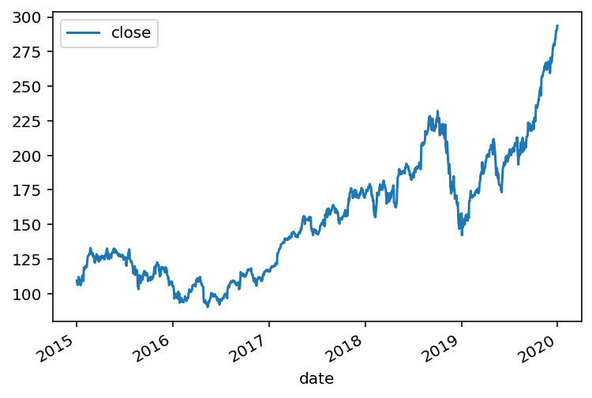

```python
# 라인 그래프 표시
stock1519.plot(kind='line', x='date',  y='close')
plt.show()
```

**2) 전일 종가와 같이 분석**

- 전일 종가도 같이 표시해 봅니다.
- **y=['close', 'p_close']**와 같이 두 열을 y 축 값으로 지정하면 됩니다.

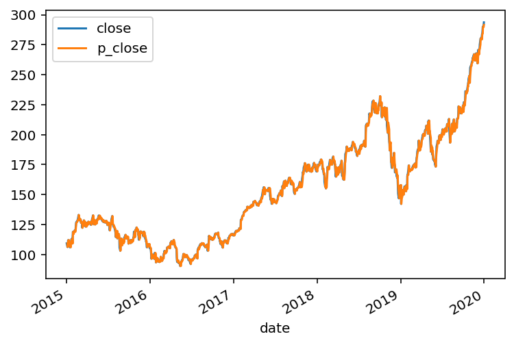

```python
# 종가, 전일 종가 라인 그래프 표시
stock1519.plot(kind='line', x='date', y=['close', 'p_close'])
plt.show()
```

- 종가와 전일 종가 차이가 미세해 잘 구분되지 않습니다.
- 2019년 12월 데이터만을 대상으로 하면 종가와 전일 종가가 구분될 것입니다.
- 2019년 12월 데이터만을 갖는 stock1912 데이터프레임을 만들어 선 그래프를 표시해봅니다.

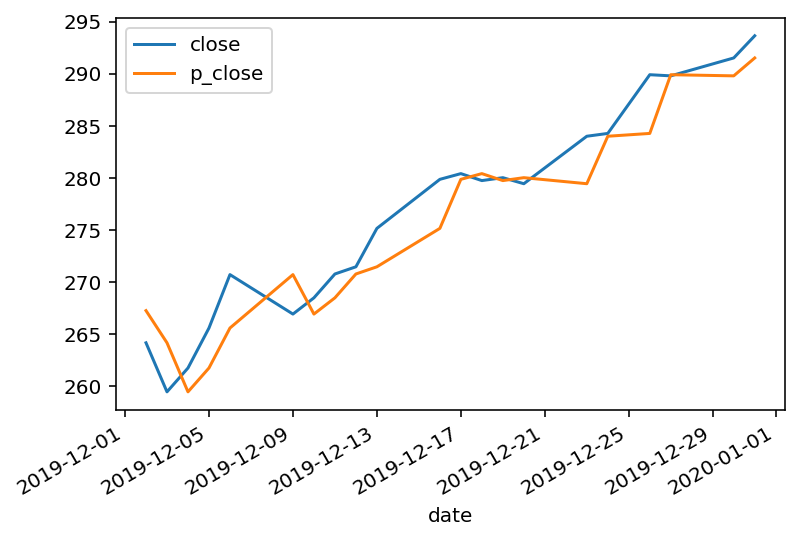

```python
# 2019-12 라인 그래프 표시
stock1912 = stock1519[stock1519['date'].between('2019-12-01', '2019-12-31')]
stock1912.plot(kind='line', x='date', y=['close', 'p_close'])
plt.show()
```

**3) 최근 3일, 7일 종가 평균과 비교**

- 2019년 12월 종가, 최근 3일 종가 평균, 7일 종가 평균을 같이 비교해 봅니다.

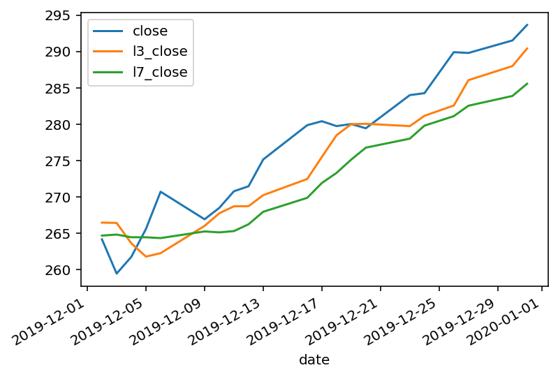

```python
# 2019-12 라인 그래프 표시
stock1912.plot(kind='line', x='date', y=['close', 'l3_close', 'l7_close'])
plt.show()
```

**4) 시가와 종가 비교**

- 2019년 12월 시가와 종가 차이를 **막대 그래프**로 표시해 봅니다.

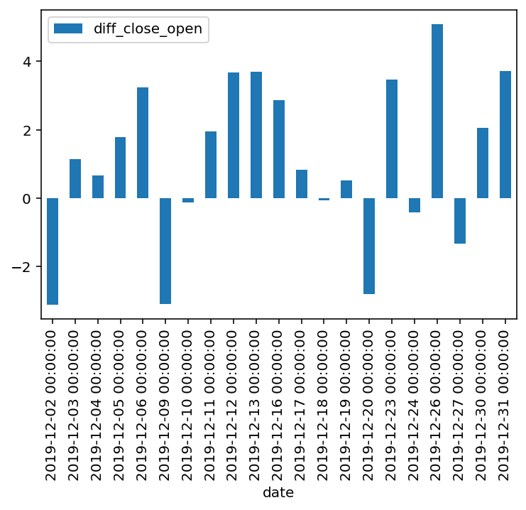

```python
# 2019-12 라인 그래프 표시
stock1912.plot(kind='bar', x='date', y=['diff_close_open'])
plt.show()
```

## 6. 의미 찾기

- 데이터 분석을 제대로 하려면 제대로된 데이터가 있어야 합니다.
- 다양한 전처리 방법을 사용해 분석이 용이한 형태로 데이터를 변경해야 합니다.
- 기존 데이터를 활용해 새로운 데이터를 만들 수 있어야 합니다.
- 회사 주가를 사용해 위와 같은 과정으로 분석을 해보면 좋을 것입니다.

## 수고하셨습니다.

[figure not shown]